# Predicting the class of the exercise

Parthiban Malan

13th August 2018

### Executive Summary

Many fitness enthusiasts collect data about their personal activities to improve their health and to find patterns in their behaviour using devices like Jawbone Up, Nike FuelBand, Fitbit etc. These people quantify **how much** of a particular activity they do, but they rarely quantify **how well** they do it. The purpose of this assignment is to use the barbell lifts data from accelerometers on the belt, forearm, arm, and dumbell of 6 participants and to predict the manner in which they did the exercise. The details about the datasets are available at http://groupware.les.inf.puc-rio.br/har.

### Synopsis

Following are the steps performed in building the model.

1. The dataset is downloaded and loaded into dataframes.
2. The training dataset is explored and key columns are identified.
3. New datasets are created with the selected columns.
4. They are then checked whether they conatin any missing values.
5. The character columns are changed to factor data types
6. The training dataset is split into 2 in the ratio 70:30 for training and validation datasets.
7. ML models are built using Classification Trees, Gradient Boosting and Random Forest algorithms.
8. The testing data is scored with best performing model.

```r
training_data_file <- paste0(getwd(),"/pml-training.csv")
if (!file.exists(training_data_file)) {
  download.file(training_data_url, training_data_file, quiet=TRUE)
}
```

```r
testing_data_file <- paste0(getwd(),"/pml-testing.csv")
if (!file.exists(testing_data_file)) {
  download.file(testing_data_url, testing_data_file, quiet=TRUE)
}
```

### Create datasets

```r
training_raw_df <- read.csv(training_data_file, header=TRUE, stringsAsFactors=FALSE)
dim(training_raw_df)
```

```
## [1] 19622   160
```

```r
testing_raw_df <- read.csv(testing_data_file, header=TRUE, stringsAsFactors=FALSE)
dim(testing_raw_df)
```

```
## [1]  20 160
```

### Understand structure of the datasets

```r
str(training_raw_df)
```

```
## 'data.frame':    19622 obs. of  160 variables:
##  $ X                       : int  1 2 3 4 5 6 7 8 9 10 ...
##  $ user_name               : chr  "carlitos" "carlitos" "carlitos" "carlitos" ...
##  $ raw_timestamp_part_1    : int  1323084231 1323084231 1323084231 1323084232 1323084232 1323084232 1323084232 1323084232 1323084232 1323084232 ...
##  $ raw_timestamp_part_2    : int  788290 808298 820366 120339 196328 304277 368296 440390 484323 484434 ...
##  $ cvtd_timestamp          : chr  "05/12/2011 11:23" "05/12/2011 11:23" "05/12/2011 11:23" "05/12/2011 11:23" ...
##  $ new_window              : chr  "no" "no" "no" "no" ...
##  $ num_window              : int  11 11 11 12 12 12 12 12 12 12 ...
##  $ roll_belt               : num  1.41 1.41 1.42 1.48 1.48 1.45 1.42 1.42 1.43 1.45 ...
##  $ pitch_belt              : num  8.07 8.07 8.07 8.05 8.07 8.06 8.09 8.13 8.16 8.17 ...
##  $ yaw_belt                : num  -94.4 -94.4 -94.4 -94.4 -94.4 -94.4 -94.4 -94.4 -94.4 -94.4 ...
##  $ total_accel_belt        : int  3 3 3 3 3 3 3 3 3 3 ...
##  $ kurtosis_roll_belt      : chr  "" "" "" "" ...
##  $ kurtosis_picth_belt     : chr  "" "" "" "" ...
##  $ kurtosis_yaw_belt       : chr  "" "" "" "" ...
```

[output cut: 86 more lines]

### Explore datasets to identify key columns

```r
head(training_raw_df)
tail(training_raw_df)
summary(training_raw_df)
```

After exploring sample data and the summary statistics, I see columns named “kurtosis”, “skewness”, “max”, “min”, “amplitude”, “var”, “avg”, “stddev” have no data. Hnece they are removed.

```r
selected_columns <-
  !grepl("kurtosis_", names(training_raw_df)) &
  !grepl("skewness_", names(training_raw_df)) &
  !grepl("max_", names(training_raw_df)) &
  !grepl("min_", names(training_raw_df)) &
  !grepl("amplitude_", names(training_raw_df)) &
  !grepl("var_", names(training_raw_df)) &
  !grepl("avg_", names(training_raw_df)) &
  !grepl("stddev_", names(training_raw_df))
training_df <- training_raw_df[ , selected_columns]
training_df[1:7] <- NULL
testing_df <- testing_raw_df[ , selected_columns]
testing_df[1:7] <- NULL
```

### Check for missing values

```r
colnames(training_df)[colSums(is.na(training_df)) > 0]
```

```
## character(0)
```

```r
colnames(testing_df)[colSums(is.na(testing_df)) > 0]
```

```
## character(0)
```

Since there are no columns with missing values, no further action is performed.

### Convert character columns into factors

```r
training_df$classe <- as.factor(training_df$classe)
```

### Split training dataset into training and testing datasets

```r
inTraining <- createDataPartition(training_df$classe, p=0.7, list=FALSE)
training_trn_df <- training_df[inTraining, ]
dim(training_trn_df)
```

```
## [1] 13737    53
```

```r
training_tst_df <- training_df[-inTraining, ]
dim(training_tst_df)
```

```
## [1] 5885   53
```

The split is perfomed to avoid overfitting the model with the entire training dataset. Cross-validation technique with 5 folds is also leveraged to prevent overfitting.

```r
trainingControl <- trainControl(method="cv", number=5)
```

### Build models

#### Using Classification Tree (CT) algorithm

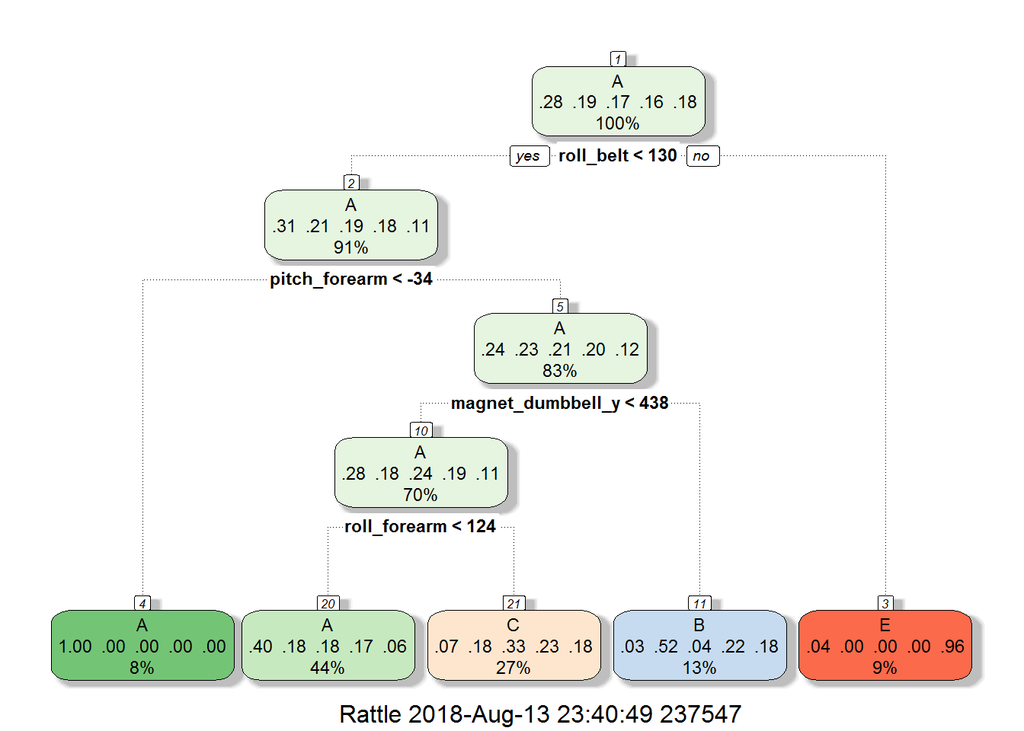

```r
model_with_CT <- train(classe ~ ., data=training_trn_df, method="rpart",  trControl=trainingControl)

fancyRpartPlot(model_with_CT$finalModel)
```

```r
predict_with_CT <- predict(model_with_CT, newdata=training_tst_df)

conf_matrix_CT <- confusionMatrix(training_tst_df$classe, predict_with_CT)
conf_matrix_CT$table
```

```
##           Reference
## Prediction    A    B    C    D    E
##          A 1481   35  131    0   27
##          B  474  379  286    0    0
##          C  484   36  506    0    0
##          D  428  188  348    0    0
##          E  134  155  276    0  517
```

```r
conf_matrix_CT$overall[1]
```

```
##  Accuracy
## 0.4898895
```

#### Using Gradient Boosting (GB) algorithm

```r
model_with_GB <- train(classe ~ ., data=training_trn_df, method="gbm",  trControl=trainingControl,
verbose=FALSE)

print(model_with_GB)
```

```
## Stochastic Gradient Boosting
##
## 13737 samples
##    52 predictor
##     5 classes: 'A', 'B', 'C', 'D', 'E'
##
## No pre-processing
## Resampling: Cross-Validated (5 fold)
## Summary of sample sizes: 10990, 10989, 10989, 10989, 10991
## Resampling results across tuning parameters:
##
##   interaction.depth  n.trees  Accuracy   Kappa
##   1                   50      0.7589722  0.6945148
##   1                  100      0.8223773  0.7752202
##   1                  150      0.8537528  0.8149792
##   2                   50      0.8553539  0.8167451
##   2                  100      0.9087133  0.8844957
##   2                  150      0.9344840  0.9171209
##   3                   50      0.8980850  0.8710075
##   3                  100      0.9445299  0.9298199
##   3                  150      0.9617096  0.9515545
##
## Tuning parameter 'shrinkage' was held constant at a value of 0.1
##
## Tuning parameter 'n.minobsinnode' was held constant at a value of 10
## Accuracy was used to select the optimal model using the largest value.
## The final values used for the model were n.trees = 150,
##  interaction.depth = 3, shrinkage = 0.1 and n.minobsinnode = 10.
```

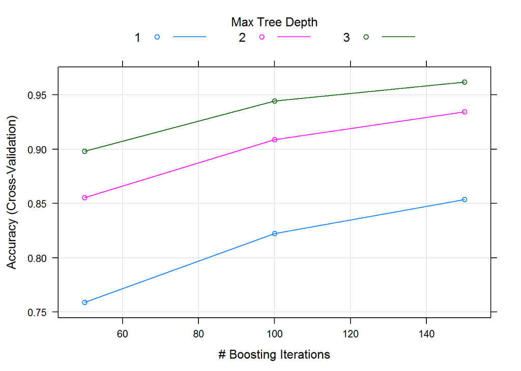

```r
plot(model_with_GB)
```

```r
predict_with_GB <- predict(model_with_GB, newdata=training_tst_df)

conf_matrix_GB <- confusionMatrix(training_tst_df$classe, predict_with_GB)
conf_matrix_GB$table
```

```
##           Reference
## Prediction    A    B    C    D    E
##          A 1642   25    2    4    1
##          B   56 1038   40    3    2
##          C    1   36  972   16    1
##          D    0    4   34  922    4
##          E    1   11   11   13 1046
```

```r
conf_matrix_GB$overall[1]
```

```
##  Accuracy
## 0.9549703
```

#### Using Random Forest (RF) algorithm

```r
model_with_RF <- train(classe ~ ., data=training_trn_df, method="rf",  trControl=trainingControl,
verbose=FALSE)

print(model_with_RF)
```

```
## Random Forest
##
## 13737 samples
##    52 predictor
##     5 classes: 'A', 'B', 'C', 'D', 'E'
##
## No pre-processing
## Resampling: Cross-Validated (5 fold)
## Summary of sample sizes: 10990, 10991, 10989, 10990, 10988
## Resampling results across tuning parameters:
##
##   mtry  Accuracy   Kappa
##    2    0.9898083  0.9871062
##   27    0.9906090  0.9881199
##   52    0.9858780  0.9821342
##
## Accuracy was used to select the optimal model using the largest value.
## The final value used for the model was mtry = 27.
```

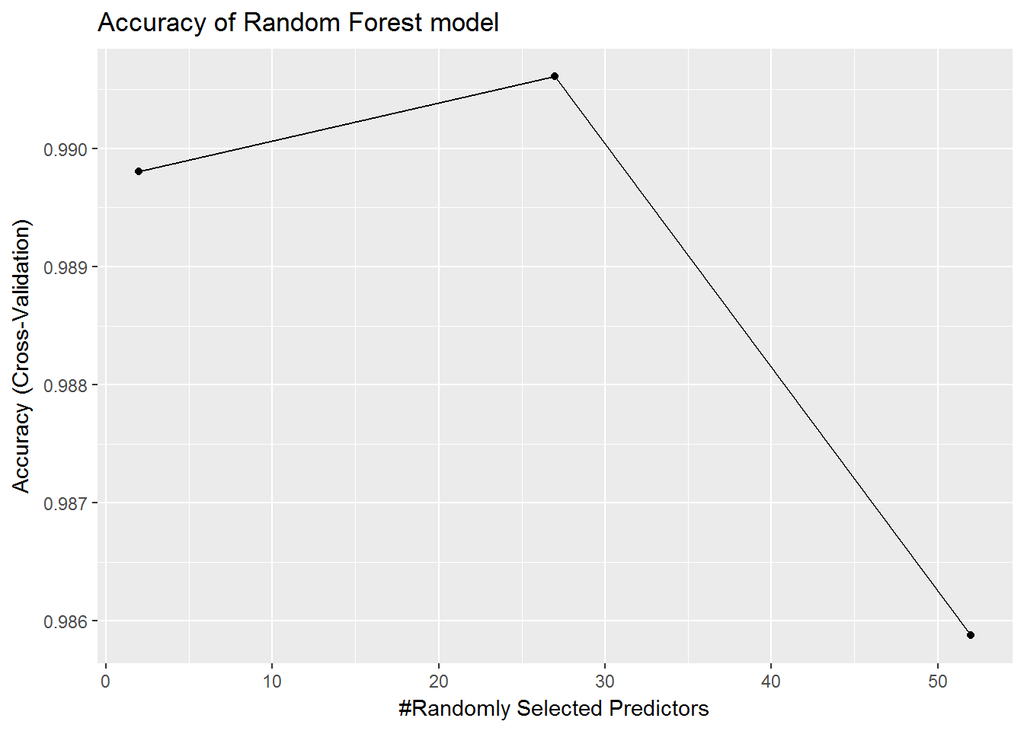

```r
p1 <- ggplot(model_with_RF)
p1 <- p1 + ggtitle("Accuracy of Random Forest model")
p1
```

```r
predict_with_RF <- predict(model_with_RF, newdata=training_tst_df)

conf_matrix_RF <- confusionMatrix(training_tst_df$classe, predict_with_RF)
conf_matrix_RF$table
```

```
##           Reference
## Prediction    A    B    C    D    E
##          A 1669    2    0    0    3
##          B    9 1127    3    0    0
##          C    0    4 1021    1    0
##          D    0    0   15  947    2
##          E    0    1    0    2 1079
```

```r
conf_matrix_RF$overall[1]
```

```
##  Accuracy
## 0.9928632
```

### Score given testing data

Of all the 3 models, the accuracy of model built with Random Forest alogithm is high. Hence I score the given testing data with that model.

```r
scored_data <- predict(model_with_RF, newdata=testing_df)
```

```r
print(data.frame(
  problem_id=testing_df$problem_id,
  predicted=scored_data, row.names = NULL
))
```

```
##    problem_id predicted
## 1           1         B
## 2           2         A
## 3           3         B
## 4           4         A
## 5           5         A
## 6           6         E
## 7           7         D
## 8           8         B
## 9           9         A
## 10         10         A
## 11         11         B
## 12         12         C
## 13         13         B
## 14         14         A
## 15         15         E
## 16         16         E
## 17         17         A
## 18         18         B
## 19         19         B
## 20         20         B
```

### Conclusion

With 0.7%, the out of sample error is least for the Random Forest model.